# Regression Modeling with `tidymodels`

Jon Geiger, Noel Goodwin, Abigail Joppa

2022-06-08

```r
library(tidyverse, warn.conflicts = F)
library(tidymodels, warn.conflicts = F)
library(tidylog)
library(ggthemes)
theme_set(theme_clean())
source("../scripts/prune_race_variables.R")
cores <- parallel::detectCores()
```

# Data Import

```r
hh <- read_csv("../data/hh.csv") %>%
    mutate(leaid = as.integer(leaid)) %>%
    filter(
        if_any(ends_with("MOE"),
               function(x) {x < 0.5})
    ) %>%
    select(-ends_with("MOE"))
```

```
##
## mutate: converted 'leaid' from double to integer (0 new NA)
##
## filter: removed 46 rows (<1%), 13,267 rows remaining
##
## select: dropped 6 variables (SP_MOE, HHVJ_MOE, CC_MOE, nci_MOE, CD_MOE, …)
```

```r
grad <- read_csv("../data/grad.csv") %>%
    mutate(leaid = as.integer(leaid))
```

```
##
## mutate: converted 'leaid' from double to integer (0 new NA)
```

```r
race <- read_csv("../data/race.csv") %>%
    prune_and_predom() %>%
    mutate(leaid = as.integer(leaid),
           predom_race = as.character(predom_race))
```

```
##
## select: dropped 59 variables (geo_id, dist, year, total_pop_est, total_pop_moe, …)
##
## mutate: converted 'leaid' from double to integer (0 new NA)
##
## select: dropped one variable (leaid)
##
## mutate: new variable 'predom_race' (factor) with 5 unique values and 0% NA
##
## select: dropped 6 variables (pct_hisp_latino, pct_white, pct_black, pct_native, pct_asian, …)
##
## mutate: converted 'predom_race' from factor to character (0 new NA)
```

```r
# assess <- read_csv("../data/assess.csv") %>%
#     mutate(leaid = as.integer(leaid))

finance <- read_csv("../data/finance.csv") %>%
    mutate(leaid = as.integer(leaid))
```

```
##
## mutate: converted 'leaid' from double to integer (0 new NA)
```

```r
data <- hh %>%
    left_join(grad,    by = c("leaid" = "leaid")) %>%
    left_join(race,    by = c("leaid" = "leaid")) %>%
#    left_join(assess,  by = c("leaid" = "leaid")) %>%
    left_join(finance, by = c("leaid" = "leaid")) %>%
    select(
        -state, -leaid, ends_with(".y")
    ) %>%
    rename_with(~ str_remove_all(.x, ".x"), ends_with(".x"))
```

```
## left_join: added one column (grad_rate_midpt)
##            > rows only in x    2,505
##            > rows only in y  ( 1,901)
##            > matched rows     10,762
##            >                 ========
##            > rows total       13,267
## left_join: added 7 columns (predom_race, pct_hisp_latino, pct_white, pct_black, pct_native, …)
##            > rows only in x    1,358
##            > rows only in y  (     1)
##            > matched rows     11,909
##            >                 ========
##            > rows total       13,267
## left_join: added 3 columns (fed_per_child, state_per_child, local_per_child)
##            > rows only in x        0
##            > rows only in y  (    47)
##            > matched rows     13,267
##            >                 ========
##            > rows total       13,267
## select: dropped 2 variables (state, leaid)
```

```r
nrow(data)
```

```
## [1] 13267
```

```r
data <- data %>%
    na.omit()

nrow(data)
```

```
## [1] 10192
```

```r
data %>% skimr::skim()
```

Data summary

| Name | Piped data |
| --- | --- |
| Number of rows | 10192 |
| Number of columns | 21 |
| _______________________ |  |
| Column type frequency: |  |
| character | 3 |
| numeric | 18 |
| ________________________ |  |
| Group variables | None |

**Variable type: character**

| skim_variable | n_missing | complete_rate | min | max | empty | n_unique | whitespace |
| --- | --- | --- | --- | --- | --- | --- | --- |
| dist | 0 | 1 | 4 | 68 | 0 | 9733 | 0 |
| region | 0 | 1 | 4 | 13 | 0 | 4 | 0 |
| predom_race | 0 | 1 | 5 | 15 | 0 | 5 | 0 |

**Variable type: numeric**

| skim_variable | n_missing | complete_rate | mean | sd | p0 | p25 | p50 | p75 | p100 | hist |
| --- | --- | --- | --- | --- | --- | --- | --- | --- | --- | --- |
| children | 0 | 1 | 5066.03 | 15935.34 | 9.00 | 720.00 | 1689.00 | 4108.50 | 724446.00 | ▇▁▁▁▁ |
| pct_pov | 0 | 1 | 0.16 | 0.09 | 0.00 | 0.10 | 0.15 | 0.21 | 0.65 | ▇▇▂▁▁ |
| pct_SP | 0 | 1 | 0.31 | 0.13 | 0.00 | 0.22 | 0.30 | 0.38 | 0.96 | ▂▇▃▁▁ |
| pct_HHVJ | 0 | 1 | 0.26 | 0.05 | 0.00 | 0.23 | 0.26 | 0.29 | 0.57 | ▁▂▇▁▁ |
| pct_CC | 0 | 1 | 0.02 | 0.03 | 0.00 | 0.01 | 0.02 | 0.03 | 0.56 | ▇▁▁▁▁ |
| pct_NCI | 0 | 1 | 0.14 | 0.11 | 0.00 | 0.06 | 0.12 | 0.19 | 0.88 | ▇▃▁▁▁ |
| pct_CD | 0 | 1 | 0.06 | 0.04 | 0.00 | 0.04 | 0.05 | 0.08 | 0.32 | ▇▅▁▁▁ |
| pct_CLI | 0 | 1 | 0.02 | 0.04 | 0.00 | 0.00 | 0.00 | 0.02 | 0.66 | ▇▁▁▁▁ |
| grad_rate_midpt | 0 | 1 | 86.08 | 7.85 | 3.23 | 82.25 | 87.85 | 91.68 | 97.93 | ▁▁▁▂▇ |
| pct_hisp_latino | 0 | 1 | 13.91 | 18.93 | 0.00 | 2.50 | 6.50 | 16.10 | 100.00 | ▇▁▁▁▁ |
| pct_white | 0 | 1 | 70.87 | 25.77 | 0.00 | 56.50 | 80.40 | 91.00 | 100.00 | ▁▁▂▃▇ |
| pct_black | 0 | 1 | 7.00 | 14.87 | 0.00 | 0.00 | 1.15 | 5.60 | 99.10 | ▇▁▁▁▁ |
| pct_native | 0 | 1 | 2.13 | 9.42 | 0.00 | 0.00 | 0.00 | 0.40 | 100.00 | ▇▁▁▁▁ |
| pct_asian | 0 | 1 | 1.86 | 4.53 | 0.00 | 0.00 | 0.20 | 1.80 | 65.20 | ▇▁▁▁▁ |
| pct_PI | 0 | 1 | 0.06 | 0.39 | 0.00 | 0.00 | 0.00 | 0.00 | 13.10 | ▇▁▁▁▁ |
| fed_per_child | 0 | 1 | 991.51 | 1323.87 | 11.51 | 517.14 | 786.57 | 1157.86 | 74305.56 | ▇▁▁▁▁ |
| state_per_child | 0 | 1 | 6579.35 | 5971.48 | 275.17 | 4271.43 | 5942.27 | 7851.77 | 393027.78 | ▇▁▁▁▁ |
| local_per_child | 0 | 1 | 6210.00 | 5804.47 | 152.86 | 3160.68 | 4832.63 | 7620.01 | 309722.22 | ▇▁▁▁▁ |

# Data Splitting and Folding

```r
set.seed(1234)
distr_split <- initial_split(data, strata = region)
distr_train <- training(distr_split)
distr_test  <- testing(distr_split)

set.seed(4321)
distr_folds <- vfold_cv(distr_train, v = 10, strata = region)
```

# Preprocessing

We can now create a recipe, or a preprocessor, which can help us by creating dummy variables for our nominal variable(s), as well as centering and scaling our predictors, and removing all near-zero-variance predictors.

```r
distr_rec <-
    recipe(grad_rate_midpt ~ ., data = distr_train) %>%
    update_role(dist, new_role = "ID") %>%
    step_interact(~ all_numeric_predictors():all_numeric_predictors()) %>%
    step_nzv(all_numeric_predictors()) %>%
    step_dummy(all_nominal_predictors()) %>%
    step_scale(all_numeric_predictors()) %>%
    step_center(all_numeric_predictors()) %>%
    step_nzv(all_numeric_predictors())
distr_rec %>%
    prep() %>%
    bake(new_data = NULL)
```

```
## # A tibble: 7,642 × 140
##    dist          children pct_pov pct_SP pct_HHVJ pct_CC pct_NCI  pct_CD pct_CLI
##    <fct>            <dbl>   <dbl>  <dbl>    <dbl>  <dbl>   <dbl>   <dbl>   <dbl>
##  1 Casey-Westfi…   -0.247  -0.199  1.12    -0.505 -0.758 -0.608   2.23   -0.492
##  2 Blue Ridge C…   -0.266  -0.544  0.265    1.42  -0.259 -0.105  -1.19   -0.492
##  3 Prairie Cent…   -0.191  -0.588 -0.259   -0.709 -0.402 -0.0651 -0.0501 -0.0603
##  4 Eastland Com…   -0.270  -0.438 -0.839   -1.10  -0.822 -0.857   0.0936 -0.492
##  5 Goreville Co…   -0.268  -0.651 -0.427   -1.55  -0.719 -0.435  -1.25   -0.492
##  6 Joppa-Maple …   -0.283   0.822 -0.526   -0.498  1.50   3.37   -0.258  -0.492
##  7 Farmington C…   -0.222  -0.645 -0.460    0.536 -0.331 -0.562   0.268  -0.492
##  8 Gallatin Com…   -0.260   1.07   1.23    -0.939 -0.356 -0.283   2.54   -0.492
##  9 Georgetown-R…   -0.240   0.565  0.110    0.116 -0.520  0.153  -0.0723 -0.492
## 10 Norris City-…   -0.256   0.201 -0.340   -1.21  -0.593 -0.238   1.12   -0.492
## # … with 7,632 more rows, and 131 more variables: pct_hisp_latino <dbl>,
## #   pct_white <dbl>, pct_black <dbl>, fed_per_child <dbl>,
## #   state_per_child <dbl>, local_per_child <dbl>, grad_rate_midpt <dbl>,
## #   children_x_pct_pov <dbl>, children_x_pct_SP <dbl>,
## #   children_x_pct_HHVJ <dbl>, children_x_pct_CC <dbl>,
## #   children_x_pct_NCI <dbl>, children_x_pct_CD <dbl>,
## #   children_x_pct_CLI <dbl>, children_x_pct_hisp_latino <dbl>, …
```

# Model Specifications

We’ll now create some specifications, or types of models, which we will integrate into our workflow. We’ll make the following models:

- Linear Regression (`lm`)
- Lasso Regression (`glmnet`)
- (NOT WORKING) Partial Least Squares (`mixOmics`)
- Multivariate Adaptive Regression Spline (`earth`)
- Support Vector Regression (`kernlab`)
- Decision Tree (`rpart`)
- Random Forest (`ranger`)
- Gradient Boosted Trees (`xgboost`)
- K-Nearest Neighbors (`kknn`)

```r
lm_spec <-
    linear_reg() %>%
    set_engine('lm')

lasso_spec <-
    linear_reg(
        mixture = 1,
        penalty = tune()
    ) %>%
    set_engine('glmnet')

pls_spec <-
    pls(
        predictor_prop = tune(),
        num_comp = tune()
    ) %>%
    set_engine('mixOmics') %>%
    set_mode('regression')

mars_spec <-
    mars(
        prod_degree = tune()
    ) %>%
    set_engine('earth') %>%
    set_mode('regression')

svm_spec <-
    svm_linear(
        cost = tune(),
        margin = tune()
    ) %>%
    set_engine('kernlab') %>%
    set_mode('regression')

dtree_spec <-
    decision_tree(
        tree_depth = tune(),
        min_n = tune(),
        cost_complexity = tune()
    ) %>%
    set_engine('rpart') %>%
    set_mode('regression')

rf_spec <-
    rand_forest(
        trees = 1000,
        mtry = tune(),
        min_n = tune()
    ) %>%
    set_engine('ranger', num.threads = cores, importance = "impurity") %>%
    set_mode('regression')

xgb_spec <-
    boost_tree(
        trees = 1000,
        tree_depth = tune(),
        min_n = tune(),
        mtry = tune(),
        sample_size = tune(),
        learn_rate = tune()
    ) %>%
    set_engine("xgboost") %>%
    set_mode("regression")

# knn_spec <-
#     nearest_neighbor(
#         neighbors = tune(),
#         weight_func = tune(),
#         dist_power = tune()
#     ) %>%
#     set_engine('kknn') %>%
#     set_mode('regression')
```

Now that we have our model specifications, we can put all of these into a workflow set.

```r
distr_workflowset <-
    workflow_set(
        preproc = list("rec" = distr_rec),
        models = list(
            "lm" = lm_spec,
            "lasso" = lasso_spec,
            # "pls" = pls_spec,
            "mars" = mars_spec,
            "svm" = svm_spec,
            "dtree" = dtree_spec,
            "rf" = rf_spec,
            "xgboost" = xgb_spec
            # "knn" = knn_spec
        )
    ) %>%
    mutate(wflow_id = wflow_id %>% str_remove_all("rec_"))
```

```
## mutate: changed 7 values (100%) of 'wflow_id' (0 new NA)
```

```r
distr_workflowset
```

```
## # A workflow set/tibble: 7 × 4
##   wflow_id info             option    result
##   <chr>    <list>           <list>    <list>
## 1 lm       <tibble [1 × 4]> <opts[0]> <list [0]>
## 2 lasso    <tibble [1 × 4]> <opts[0]> <list [0]>
## 3 mars     <tibble [1 × 4]> <opts[0]> <list [0]>
## 4 svm      <tibble [1 × 4]> <opts[0]> <list [0]>
## 5 dtree    <tibble [1 × 4]> <opts[0]> <list [0]>
## 6 rf       <tibble [1 × 4]> <opts[0]> <list [0]>
## 7 xgboost  <tibble [1 × 4]> <opts[0]> <list [0]>
```

# Model Training

We can now tune our models:

```r
distr_grid_ctrl <-
    control_grid(
        save_pred = TRUE,
        parallel_over = "everything",
        save_workflow = TRUE
    )

doParallel::registerDoParallel(cores = cores)
distr_tune <-
    distr_workflowset %>%
    workflow_map("tune_grid", seed = 2314,
                resamples = distr_folds,
                grid = 30,
                control = distr_grid_ctrl,
                verbose = TRUE)

saveRDS(distr_tune, paste0("trained_models/", Sys.Date(), "_distr_tune.rds"))
```

```
i 1 of 7 resampling: lm
✔ 1 of 7 resampling: lm (7.2s)
i 2 of 7 tuning:     lasso
✔ 2 of 7 tuning:     lasso (7.5s)
i 3 of 7 tuning:     mars
✔ 3 of 7 tuning:     mars (31.5s)
i 4 of 7 tuning:     svm
✔ 4 of 7 tuning:     svm (1h 32m 55.8s)
i 5 of 7 tuning:     dtree
✔ 5 of 7 tuning:     dtree (4m 18.9s)
i 6 of 7 tuning:     rf
✔ 6 of 7 tuning:     rf (2h 35m 19.7s)
i 7 of 7 tuning:     xgboost
✔ 7 of 7 tuning:     xgboost (32m 56.5s)
```

# Model Evaluation

```r
distr_tune <- readRDS("trained_models/2022-05-25_distr_tune.rds")
```

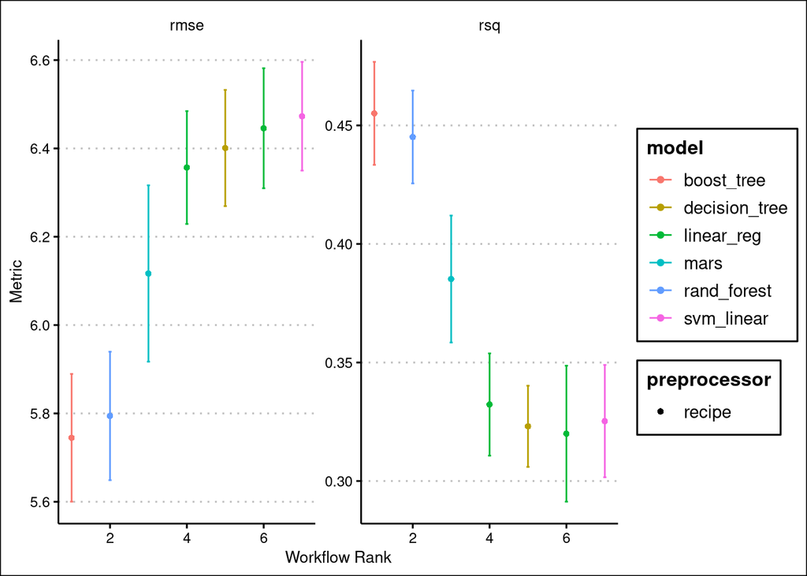

```r
autoplot(distr_tune, select_best = TRUE)
```

```r
(ranks <- distr_tune %>%
    rank_results(select_best = TRUE) %>%
    select(-std_err) %>%
    pivot_wider(names_from = .metric, values_from = mean) %>%
    select(wflow_id, rank, rmse, rsq))
```

```
## select: dropped one variable (std_err)
```

```
## pivot_wider: reorganized (.metric, mean) into (rmse, rsq) [was 14x8, now 7x8]
```

```
## select: dropped 4 variables (.config, n, preprocessor, model)
```

```
## # A tibble: 7 × 4
##   wflow_id  rank  rmse   rsq
##   <chr>    <int> <dbl> <dbl>
## 1 xgboost      1  5.74 0.455
## 2 rf           2  5.79 0.445
## 3 mars         3  6.12 0.385
## 4 lasso        4  6.36 0.332
## 5 dtree        5  6.40 0.323
## 6 lm           6  6.45 0.320
## 7 svm          7  6.47 0.325
```

```r
(best_wflow_id <- ranks %>%
    head(1) %>% pull(wflow_id))
```

```
## [1] "xgboost"
```

```r
best_results <-
    distr_tune %>%
    extract_workflow_set_result(best_wflow_id) %>%
    select_best(metric = "rmse")

rf_results <-
    distr_tune %>%
    extract_workflow_set_result("rf") %>%
    select_best(metric = "rmse")

best_results
```

```
## # A tibble: 1 × 6
##    mtry min_n tree_depth learn_rate sample_size .config
##   <int> <int>      <int>      <dbl>       <dbl> <chr>
## 1    19    13         11    0.00565       0.960 Preprocessor1_Model10
```

```r
rf_results
```

```
## # A tibble: 1 × 3
##    mtry min_n .config
##   <int> <int> <chr>
## 1   104    13 Preprocessor1_Model23
```

```r
test_results <-
    distr_tune %>%
    extract_workflow(best_wflow_id) %>%
    finalize_workflow(best_results) %>%
    last_fit(split = distr_split)

rf_test_results <-
    distr_tune %>%
    extract_workflow("rf") %>%
    finalize_workflow(rf_results) %>%
    last_fit(split = distr_split)

collect_metrics(test_results)
```

```
## # A tibble: 2 × 4
##   .metric .estimator .estimate .config
##   <chr>   <chr>          <dbl> <chr>
## 1 rmse    standard       5.98  Preprocessor1_Model1
## 2 rsq     standard       0.450 Preprocessor1_Model1
```

```r
collect_metrics(rf_test_results)
```

```
## # A tibble: 2 × 4
##   .metric .estimator .estimate .config
##   <chr>   <chr>          <dbl> <chr>
## 1 rmse    standard       6.06  Preprocessor1_Model1
## 2 rsq     standard       0.435 Preprocessor1_Model1
```

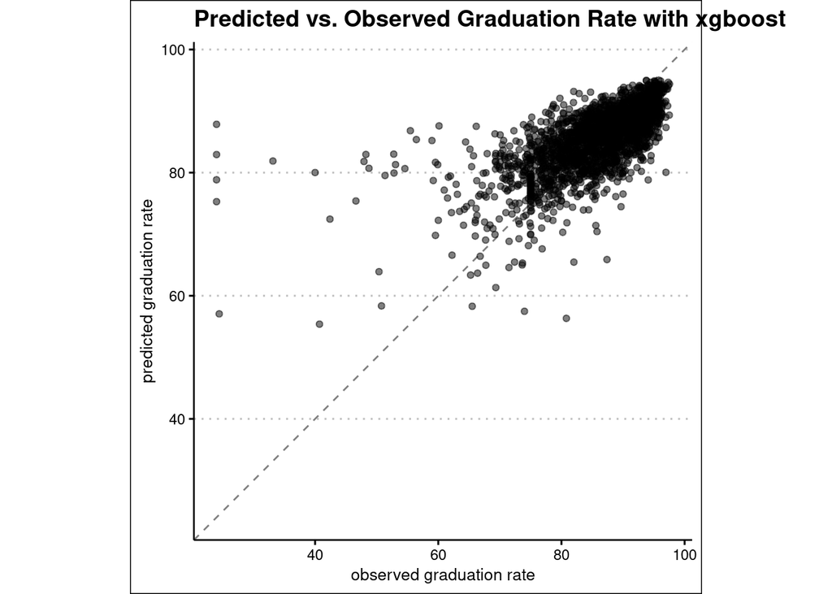

```r
test_results %>%
    collect_predictions() %>%
    ggplot(aes(x = grad_rate_midpt, y = .pred)) +
    geom_abline(color = "gray50", lty = 2) +
    geom_point(alpha = 0.5) +
    coord_obs_pred() +
    labs(x = "observed graduation rate", y = "predicted graduation rate",
         title = paste0("Predicted vs. Observed Graduation Rate with ", best_wflow_id))
```

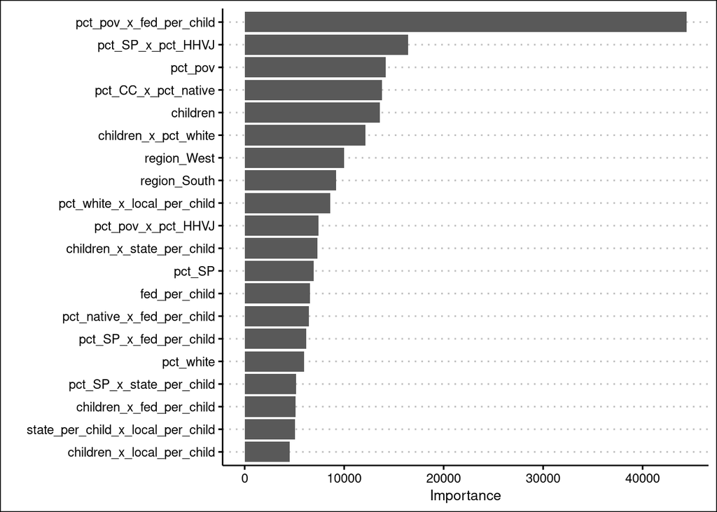

```r
library(vip)
rf_test_results %>%
    extract_fit_parsnip() %>%
    vip(num_features = 20)
```